## BRC Census

# Sociodemographic Characteristics

## BRC Population, Past Burning Man Experience, Age, Ethnicity, Education, Income, and Creative Self-Identities

## BRC Population*

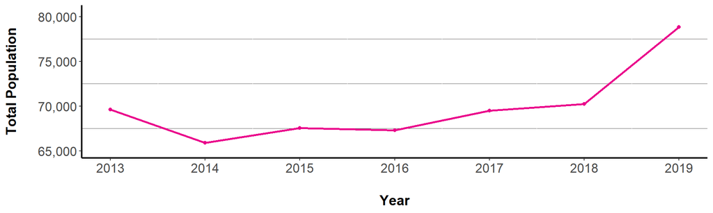

*The population count was changed in 2019 to include BRC staff, government workers, and volunteers in addition to paid participants. The number of paid participants and the maximum occupancy of BRC was similar to 2018.

From https://burningman.org/timeline/

## Past Burning Man Experience

**Percent Virgins**  
**2013:** 38.6% **2014:** 35.1% **2015:** 35.8% **2016:** 39.3% **2017:** 36.2% **2018:** 31.7% **2019:** 25.9%

# Number of Burns Attended

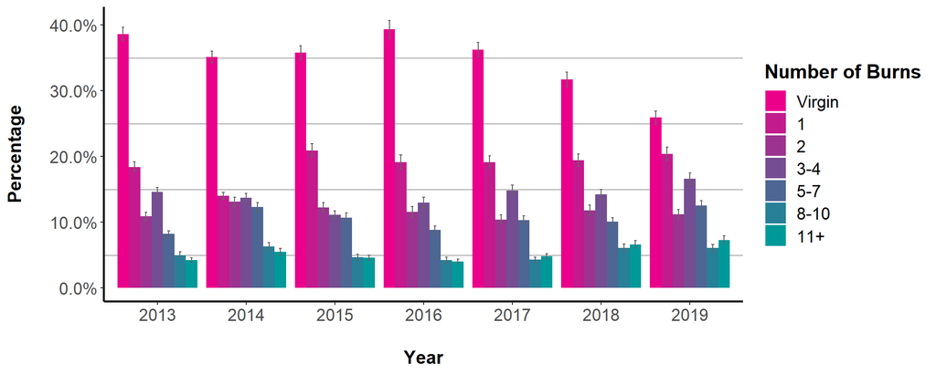

Error bars indicate the upper and lower bounds of the 95% confidence intervals.

|  | 2013 Percent | 2013 MoE +/- % |  | 2014 Percent | 2014 MoE +/- % |  | 2015 Percent | 2015 MoE +/- % |  | 2016 Percent | 2016 MoE +/- % |  | 2017 Percent | 2017 MoE +/- % |  | 2018 Percent | 2018 MoE +/- % |  | 2019 Percent | 2019 MoE +/- % |
| --- | --- | --- | --- | --- | --- | --- | --- | --- | --- | --- | --- | --- | --- | --- | --- | --- | --- | --- | --- | --- |
| Virgin | 38.6 | 1.0 |  | 35.1 | 1.0 |  | 35.8 | 1.0 |  | 39.3 | 1.4 |  | 36.2 | 1.2 |  | 31.7 | 1.2 |  | 25.9 | 1.0 |
| 1 | 18.4 | 0.8 |  | 14.0 | 0.6 |  | 20.9 | 1.0 |  | 19.1 | 1.0 |  | 19.1 | 1.0 |  | 19.4 | 1.0 |  | 20.4 | 1.0 |
| 2 | 10.9 | 0.6 |  | 13.1 | 0.8 |  | 12.2 | 0.8 |  | 11.6 | 0.8 |  | 10.4 | 0.6 |  | 11.8 | 0.8 |  | 11.2 | 0.8 |
| 3-4 | 14.6 | 0.8 |  | 13.7 | 0.8 |  | 11.1 | 0.6 |  | 13.0 | 0.8 |  | 14.8 | 0.8 |  | 14.2 | 0.8 |  | 16.6 | 1.0 |
| 5-7 | 8.2 | 0.4 |  | 12.3 | 0.8 |  | 10.7 | 0.8 |  | 8.8 | 0.6 |  | 10.3 | 0.6 |  | 10.1 | 0.6 |  | 12.5 | 0.8 |
| 8-10 | 5.0 | 0.4 |  | 6.3 | 0.6 |  | 4.7 | 0.4 |  | 4.2 | 0.4 |  | 4.3 | 0.4 |  | 6.1 | 0.6 |  | 6.1 | 0.6 |
| 11+ | 4.2 | 0.4 |  | 5.5 | 0.6 |  | 4.6 | 0.4 |  | 4.0 | 0.4 |  | 4.8 | 0.4 |  | 6.6 | 0.6 |  | 7.3 | 0.6 |

## Past Burning Man Experience

# Years Since First Burn

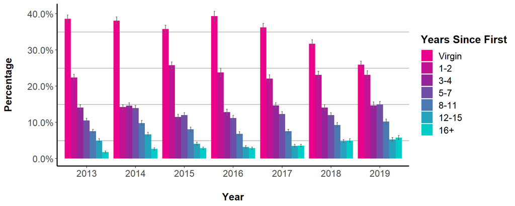

Error bars indicate the upper and lower bounds of the 95% confidence intervals.

|  | 2013 Percent | 2013 MoE +/- % |  | 2014 Percent | 2014 MoE +/- % |  | 2015 Percent | 2015 MoE +/- % |  | 2016 Percent | 2016 MoE +/- % |  | 2017 Percent | 2017 MoE +/- % |  | 2018 Percent | 2018 MoE +/- % |  | 2019 Percent | 2019 MoE +/- % |
| --- | --- | --- | --- | --- | --- | --- | --- | --- | --- | --- | --- | --- | --- | --- | --- | --- | --- | --- | --- | --- |
| Virgin | 38.6 | 1.0 |  | 38.1 | 1.0 |  | 35.8 | 1.0 |  | 39.3 | 1.4 |  | 36.2 | 1.2 |  | 31.7 | 1.2 |  | 25.9 | 1.0 |
| 1-2 | 22.4 | 0.8 |  | 14.2 | 0.8 |  | 25.8 | 1.0 |  | 23.8 | 1.2 |  | 22.1 | 1.0 |  | 23.1 | 1.0 |  | 23.1 | 1.0 |
| 3-4 | 14.1 | 0.6 |  | 14.6 | 0.8 |  | 11.5 | 0.6 |  | 12.8 | 0.8 |  | 14.7 | 0.8 |  | 14.1 | 0.8 |  | 14.7 | 0.8 |
| 5-7 | 10.5 | 0.6 |  | 13.9 | 0.8 |  | 12.0 | 0.8 |  | 11.2 | 0.8 |  | 12.3 | 0.6 |  | 12.0 | 0.8 |  | 15.0 | 0.8 |
| 8-11 | 7.6 | 0.6 |  | 9.8 | 0.8 |  | 8.1 | 0.6 |  | 6.8 | 0.6 |  | 7.6 | 0.6 |  | 9.3 | 0.6 |  | 10.2 | 0.8 |
| 12-15 | 5.0 | 0.4 |  | 6.7 | 0.6 |  | 4.1 | 0.4 |  | 3.2 | 0.4 |  | 3.5 | 0.4 |  | 4.8 | 0.4 |  | 5.3 | 0.6 |
| 16+ | 1.8 | 0.2 |  | 2.7 | 0.4 |  | 2.9 | 0.4 |  | 2.9 | 0.4 |  | 3.6 | 0.4 |  | 5.0 | 0.4 |  | 5.8 | 0.6 |

*Because many Burners attend repeatedly, but not every year, the random sampling form and online survey both ask respondents to indicate each of the year(s) they have attended Burning Man.*

## Age

**Median Age**  
**2013:** 33 **2014:** 34 **2015:** 33 **2016:** 34 **2017:** 34 **2018:** 35 **2019:** 36

# Age Range

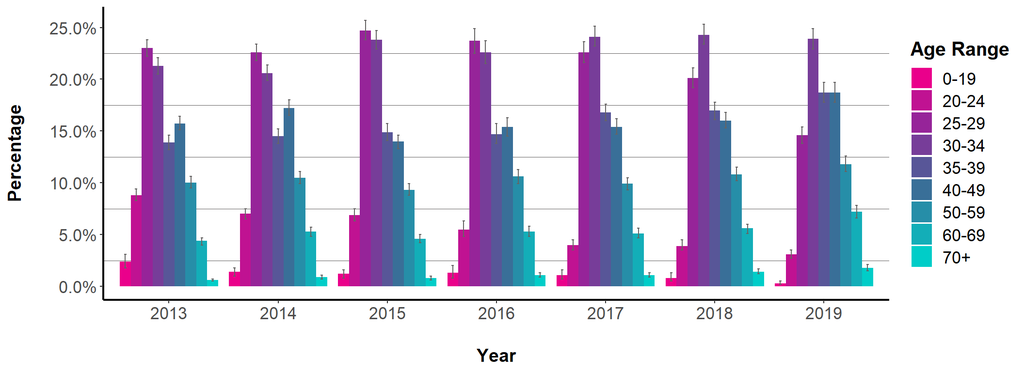

Error bars indicate the upper and lower bounds of the 95% confidence intervals.

|  | 2013 Percent | 2013 MoE +/- % |  | 2014 Percent | 2014 MoE +/- % |  | 2015 Percent | 2015 MoE +/- % |  | 2016 Percent | 2016 MoE +/- % |  | 2017 Percent | 2017 MoE +/- % |  | 2018 Percent | 2018 MoE +/- % |  | 2019 Percent | 2019 MoE +/- % |
| --- | --- | --- | --- | --- | --- | --- | --- | --- | --- | --- | --- | --- | --- | --- | --- | --- | --- | --- | --- | --- |
| 0-19 | 2.4 | 0.6 |  | 1.4 | 0.4 |  | 1.2 | 0.4 |  | 1.3 | 0.6 |  | 1.1 | 0.4 |  | 0.8 | 0.4 |  | 0.3 | 0.2 |
| 20-24 | 8.8 | 0.6 |  | 7.0 | 0.6 |  | 6.9 | 0.6 |  | 5.5 | 0.8 |  | 4.0 | 0.4 |  | 3.9 | 0.6 |  | 3.1 | 0.4 |
| 25-29 | 23.0 | 0.8 |  | 22.6 | 0.8 |  | 24.7 | 1.0 |  | 23.7 | 1.2 |  | 22.6 | 1.0 |  | 20.1 | 1.0 |  | 14.6 | 0.8 |
| 30-34 | 21.3 | 0.8 |  | 20.6 | 0.8 |  | 23.8 | 1.0 |  | 22.6 | 1.2 |  | 24.1 | 1.0 |  | 24.3 | 1.0 |  | 23.9 | 1.0 |
| 35-39 | 13.9 | 0.6 |  | 14.5 | 0.8 |  | 14.9 | 0.8 |  | 14.7 | 1.0 |  | 16.8 | 0.8 |  | 17.0 | 0.8 |  | 18.7 | 1.0 |
| 40-49 | 15.7 | 0.6 |  | 17.2 | 0.8 |  | 14.0 | 0.6 |  | 15.4 | 1.0 |  | 15.4 | 0.8 |  | 16.0 | 0.8 |  | 18.7 | 1.0 |
| 50-59 | 10.0 | 0.6 |  | 10.5 | 0.6 |  | 9.3 | 0.6 |  | 10.6 | 0.8 |  | 9.9 | 0.6 |  | 10.8 | 0.6 |  | 11.8 | 0.8 |
| 60-69 | 4.4 | 0.4 |  | 5.3 | 0.4 |  | 4.6 | 0.4 |  | 5.3 | 0.6 |  | 5.1 | 0.4 |  | 5.6 | 0.4 |  | 7.2 | 0.6 |
| 70+ | 0.6 | 0.2 |  | 0.9 | 0.2 |  | 0.8 | 0.2 |  | 1.1 | 0.2 |  | 1.1 | 0.2 |  | 1.4 | 0.2 |  | 1.8 | 0.2 |

## Ethnicity

# Ethnicity

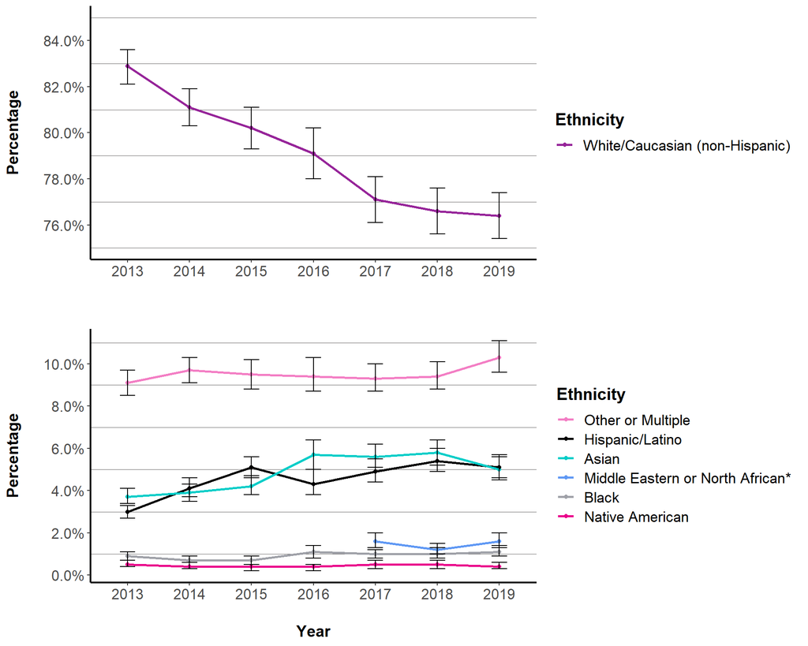

Error bars indicate the upper and lower bounds of the 95% confidence intervals.

* "Middle Eastern or North African" was first added as an option in the 2017 online survey, which may have resulted in decreases in the "White/Caucasian (non-Hispanic)" and "Other or Multiple" categories in 2017-18.

|  | 2013 Percent | 2013 MoE +/- % |  | 2014 Percent | 2014 MoE +/- % |  | 2015 Percent | 2015 MoE +/- % |  | 2016 Percent | 2016 MoE +/- % |  | 2017 Percent | 2017 MoE +/- % |  | 2018 Percent | 2018 MoE +/- % |  | 2019 Percent | 2019 MoE +/- % |
| --- | --- | --- | --- | --- | --- | --- | --- | --- | --- | --- | --- | --- | --- | --- | --- | --- | --- | --- | --- | --- |
| White/Caucasian (non-Hispanic) | 82.9 | 0.8 |  | 81.1 | 0.8 |  | 80.2 | 1.0 |  | 79.1 | 1.2 |  | 77.1 | 1.0 |  | 76.6 | 1.0 |  | 76.4 | 1.0 |
| Other or Multiple | 9.1 | 0.6 |  | 9.7 | 0.6 |  | 9.5 | 0.6 |  | 9.4 | 0.8 |  | 9.3 | 0.6 |  | 9.4 | 0.6 |  | 10.3 | 0.8 |
| Hispanic/Latino | 3.0 | 0.4 |  | 4.1 | 0.4 |  | 5.1 | 0.6 |  | 4.3 | 0.6 |  | 4.9 | 0.6 |  | 5.4 | 0.6 |  | 5.1 | 0.6 |
| Asian | 3.7 | 0.4 |  | 3.9 | 0.4 |  | 4.2 | 0.4 |  | 5.7 | 0.6 |  | 5.6 | 0.6 |  | 5.8 | 0.6 |  | 5.0 | 0.6 |
| Middle Eastern or North African* | NA | NA |  | NA | NA |  | NA | NA |  | NA | NA |  | 1.6 | 0.4 |  | 1.2 | 0.2 |  | 1.6 | 0.4 |
| Black | 0.9 | 0.2 |  | 0.7 | 0.2 |  | 0.7 | 0.2 |  | 1.1 | 0.2 |  | 1.0 | 0.2 |  | 1.0 | 0.2 |  | 1.1 | 0.2 |
| Native American | 0.5 | 0.2 |  | 0.4 | 0.2 |  | 0.4 | 0.2 |  | 0.4 | 0.2 |  | 0.5 | 0.2 |  | 0.5 | 0.2 |  | 0.4 | 0.2 |

## Self-Identification as a Person of Color

# Self-Identification as a Person of Color

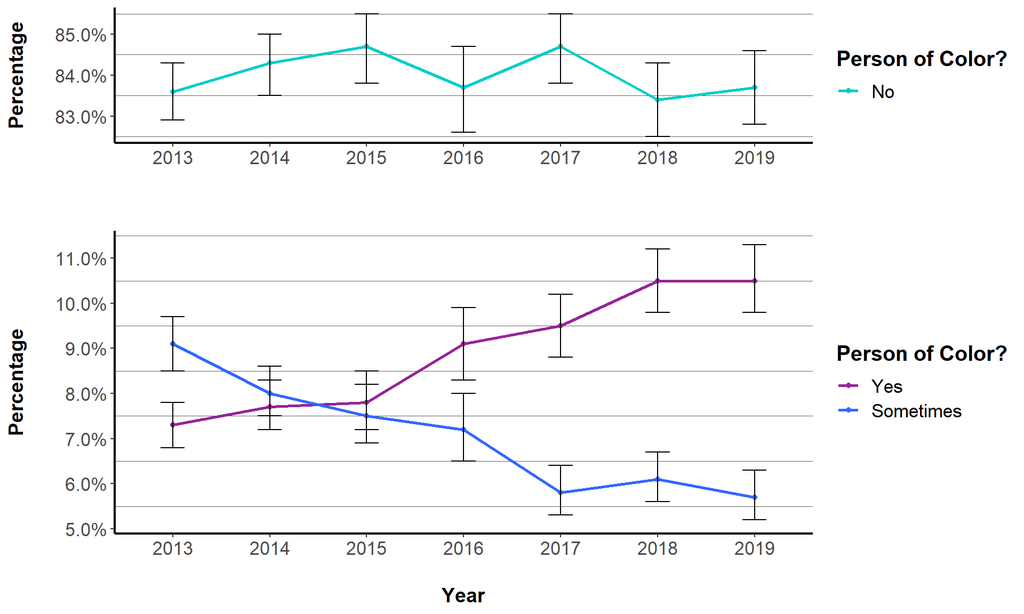

Error bars indicate the upper and lower bounds of the 95% confidence intervals.

|  | 2013 Percent | 2013 MoE +/- % |  | 2014 Percent | 2014 MoE +/- % |  | 2015 Percent | 2015 MoE +/- % |  | 2016 Percent | 2016 MoE +/- % |  | 2017 Percent | 2017 MoE +/- % |  | 2018 Percent | 2018 MoE +/- % |  | 2019 Percent | 2019 MoE +/- % |
| --- | --- | --- | --- | --- | --- | --- | --- | --- | --- | --- | --- | --- | --- | --- | --- | --- | --- | --- | --- | --- |
| No | 83.6 | 0.8 |  | 84.3 | 0.8 |  | 84.7 | 0.8 |  | 83.7 | 1.0 |  | 84.7 | 0.8 |  | 83.4 | 1.0 |  | 83.7 | 1.0 |
| Yes | 7.3 | 0.6 |  | 7.7 | 0.6 |  | 7.8 | 0.6 |  | 9.1 | 0.8 |  | 9.5 | 0.6 |  | 10.5 | 0.8 |  | 10.5 | 0.8 |
| Sometimes | 9.1 | 0.6 |  | 8.0 | 0.6 |  | 7.5 | 0.6 |  | 7.2 | 0.8 |  | 5.8 | 0.6 |  | 6.1 | 0.6 |  | 5.7 | 0.6 |

## Highest Education Achieved*

# Highest Education Achieved*

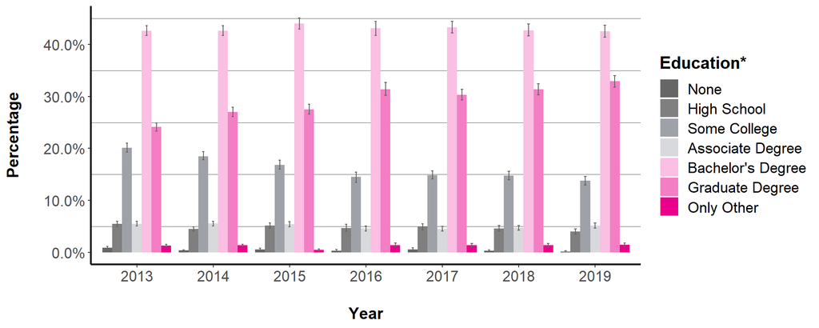

Error bars indicate the upper and lower bounds of the 95% confidence intervals.

* The precise wording of this question in the online survey has changed several times to include or exclude questions about specific certifications, but these changes were not expected to have (and do not appear to have had) a material effect on participant responses.

|  | 2013 Percent | 2013 MoE +/- % |  | 2014 Percent | 2014 MoE +/- % |  | 2015 Percent | 2015 MoE +/- % |  | 2016 Percent | 2016 MoE +/- % |  | 2017 Percent | 2017 MoE +/- % |  | 2018 Percent | 2018 MoE +/- % |  | 2019 Percent | 2019 MoE +/- % |
| --- | --- | --- | --- | --- | --- | --- | --- | --- | --- | --- | --- | --- | --- | --- | --- | --- | --- | --- | --- | --- |
| None | 0.9 | 0.2 |  | 0.4 | 0.2 |  | 0.6 | 0.2 |  | 0.3 | 0.2 |  | 0.6 | 0.2 |  | 0.3 | 0.2 |  | 0.2 | 0.2 |
| High School | 5.5 | 0.6 |  | 4.5 | 0.4 |  | 5.2 | 0.6 |  | 4.7 | 0.6 |  | 4.9 | 0.6 |  | 4.6 | 0.6 |  | 4.0 | 0.6 |
| Some College | 20.1 | 0.8 |  | 18.5 | 0.8 |  | 16.8 | 0.8 |  | 14.5 | 1.0 |  | 14.9 | 0.8 |  | 14.8 | 0.8 |  | 13.8 | 0.8 |
| Associate Degree | 5.5 | 0.4 |  | 5.6 | 0.4 |  | 5.4 | 0.6 |  | 4.6 | 0.6 |  | 4.5 | 0.4 |  | 4.7 | 0.4 |  | 5.2 | 0.6 |
| Bachelor’s Degree | 42.6 | 1.0 |  | 42.6 | 1.0 |  | 44.0 | 1.0 |  | 43.1 | 1.4 |  | 43.3 | 1.2 |  | 42.7 | 1.2 |  | 42.5 | 1.2 |
| Graduate Degree | 24.1 | 0.8 |  | 27.0 | 0.8 |  | 27.5 | 1.0 |  | 31.4 | 1.2 |  | 30.3 | 1.0 |  | 31.4 | 1.0 |  | 32.9 | 1.2 |
| Only Other | 1.3 | 0.2 |  | 1.4 | 0.2 |  | 0.5 | 0.2 |  | 1.4 | 0.4 |  | 1.4 | 0.2 |  | 1.4 | 0.2 |  | 1.5 | 0.2 |

## Income

**Median Personal Income**  
**2013:** $51,100  **2014:** $53,900  **2015:** $54,900  **2016:** $60,000  **2017:** $60,700  **2018:** $64,700  **2019:** $71,500

# Personal Income*

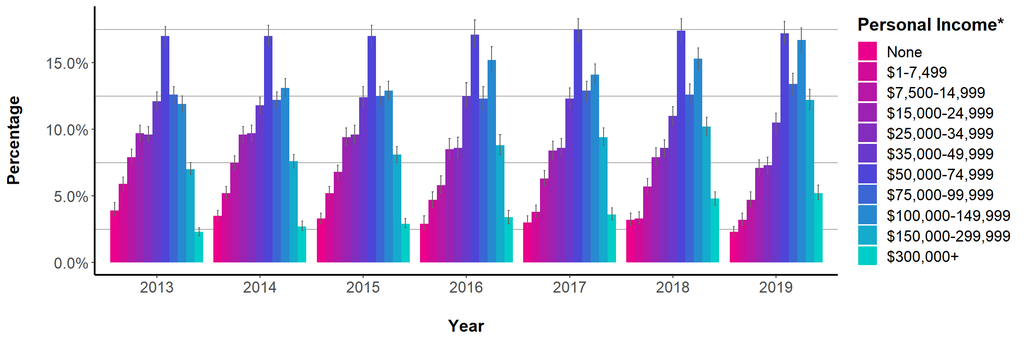

Error bars indicate the upper and lower bounds of the 95% confidence intervals.

* This question was asked slightly differently in 2013-14, 2015-16, and 2017-18. However, in all years the question explicitly asked for personal income before taxes in the previous calendar year so these changes were not expected to have (and do not appear to have had) a material effect on participant responses.

|  | 2013 Percent | 2013 MoE +/- % |  | 2014 Percent | 2014 MoE +/- % |  | 2015 Percent | 2015 MoE +/- % |  | 2016 Percent | 2016 MoE +/- % |  | 2017 Percent | 2017 MoE +/- % |  | 2018 Percent | 2018 MoE +/- % |  | 2019 Percent | 2019 MoE +/- % |
| --- | --- | --- | --- | --- | --- | --- | --- | --- | --- | --- | --- | --- | --- | --- | --- | --- | --- | --- | --- | --- |
| None | 3.9 | 0.6 |  | 3.5 | 0.4 |  | 3.3 | 0.4 |  | 2.9 | 0.6 |  | 3.0 | 0.4 |  | 3.2 | 0.4 |  | 2.3 | 0.4 |
| $1-7,499 | 5.9 | 0.6 |  | 5.2 | 0.4 |  | 5.2 | 0.6 |  | 4.7 | 0.6 |  | 3.8 | 0.4 |  | 3.3 | 0.4 |  | 3.2 | 0.4 |
| $7,500-14,999 | 7.9 | 0.6 |  | 7.5 | 0.6 |  | 6.8 | 0.6 |  | 5.8 | 0.6 |  | 6.3 | 0.6 |  | 5.7 | 0.6 |  | 4.7 | 0.6 |
| $15,000-24,999 | 9.7 | 0.6 |  | 9.6 | 0.6 |  | 9.4 | 0.6 |  | 8.5 | 0.8 |  | 8.4 | 0.6 |  | 7.9 | 0.6 |  | 7.1 | 0.6 |
| $25,000-34,999 | 9.6 | 0.6 |  | 9.7 | 0.6 |  | 9.6 | 0.6 |  | 8.6 | 0.8 |  | 8.6 | 0.6 |  | 8.6 | 0.6 |  | 7.3 | 0.6 |
| $35,000-49,999 | 12.1 | 0.6 |  | 11.8 | 0.6 |  | 12.4 | 0.8 |  | 12.5 | 1.0 |  | 12.3 | 0.8 |  | 11.0 | 0.8 |  | 10.5 | 0.8 |
| $50,000-74,999 | 17.0 | 0.8 |  | 17.0 | 0.8 |  | 17.0 | 0.8 |  | 17.1 | 1.0 |  | 17.5 | 0.8 |  | 17.4 | 0.8 |  | 17.2 | 0.8 |
| $75,000-99,999 | 12.6 | 0.6 |  | 12.2 | 0.6 |  | 12.5 | 0.8 |  | 12.3 | 0.8 |  | 12.9 | 0.8 |  | 12.6 | 0.8 |  | 13.4 | 0.8 |
| $100,000-149,999 | 11.9 | 0.6 |  | 13.1 | 0.6 |  | 12.9 | 0.8 |  | 15.2 | 1.0 |  | 14.1 | 0.8 |  | 15.3 | 0.8 |  | 16.7 | 0.8 |
| $150,000-299,999 | 7.0 | 0.4 |  | 7.6 | 0.6 |  | 8.1 | 0.6 |  | 8.8 | 0.8 |  | 9.4 | 0.6 |  | 10.2 | 0.6 |  | 12.2 | 0.8 |
| $300,000+ | 2.3 | 0.2 |  | 2.7 | 0.4 |  | 2.9 | 0.4 |  | 3.4 | 0.4 |  | 3.6 | 0.4 |  | 4.8 | 0.6 |  | 5.2 | 0.6 |

## Income

# Household Income (for the Previous Calendar Year)*

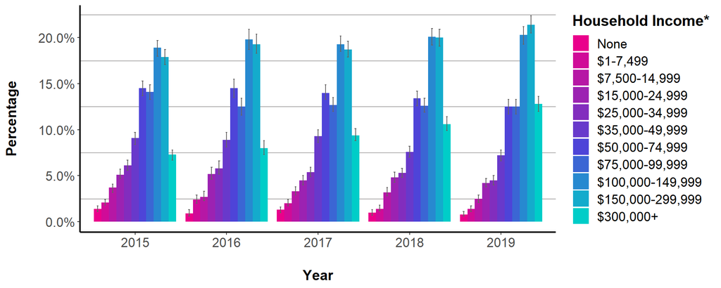

Error bars indicate the upper and lower bounds of the 95% confidence intervals.

* The plot above and table below exclude a small number of participants who indicated being a member of a household, but who chose not to disclose their household income. For participants indicating no household membership, personal income and household income are considered to be identical.

|  | 2015 Percent | 2015 MoE +/- % |  | 2016 Percent | 2016 MoE +/- % |  | 2017 Percent | 2017 MoE +/- % |  | 2018 Percent | 2018 MoE +/- % |  | 2019 Percent | 2019 MoE +/- % |
| --- | --- | --- | --- | --- | --- | --- | --- | --- | --- | --- | --- | --- | --- | --- |
| None | 1.4 | 0.2 |  | 0.9 | 0.4 |  | 1.3 | 0.2 |  | 1.0 | 0.2 |  | 0.8 | 0.2 |
| $1-7,499 | 2.1 | 0.4 |  | 2.4 | 0.4 |  | 2.0 | 0.4 |  | 1.4 | 0.2 |  | 1.4 | 0.2 |
| $7,500-14,999 | 3.7 | 0.4 |  | 2.7 | 0.4 |  | 3.3 | 0.4 |  | 3.2 | 0.4 |  | 2.5 | 0.4 |
| $15,000-24,999 | 5.1 | 0.6 |  | 5.2 | 0.6 |  | 4.5 | 0.6 |  | 4.8 | 0.6 |  | 4.2 | 0.6 |
| $25,000-34,999 | 6.1 | 0.6 |  | 5.8 | 0.6 |  | 5.4 | 0.6 |  | 5.3 | 0.6 |  | 4.5 | 0.6 |
| $35,000-49,999 | 9.1 | 0.6 |  | 8.9 | 0.8 |  | 9.3 | 0.8 |  | 7.6 | 0.6 |  | 7.2 | 0.6 |
| $50,000-74,999 | 14.5 | 0.8 |  | 14.5 | 1.0 |  | 14.0 | 0.8 |  | 13.4 | 0.8 |  | 12.5 | 0.8 |
| $75,000-99,999 | 14.1 | 0.8 |  | 12.5 | 0.8 |  | 12.7 | 0.8 |  | 12.6 | 0.8 |  | 12.5 | 0.8 |
| $100,000-149,999 | 18.9 | 0.8 |  | 19.8 | 1.0 |  | 19.3 | 1.0 |  | 20.1 | 1.0 |  | 20.3 | 1.0 |
| $150,000-299,999 | 17.9 | 0.8 |  | 19.3 | 1.0 |  | 18.7 | 0.8 |  | 20.0 | 1.0 |  | 21.4 | 1.0 |
| $300,000+ | 7.3 | 0.6 |  | 8.0 | 0.8 |  | 9.4 | 0.6 |  | 10.6 | 0.8 |  | 12.8 | 0.8 |

## Creative Self-Identities

# Self-Identification as an Artist, Maker, or Craftsperson*

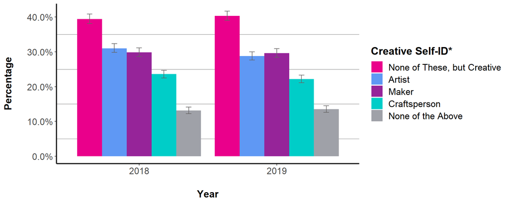

Error bars indicate the upper and lower bounds of the 95% confidence intervals.

* This question was modified in the 2018 online survey to alter include "Maker" and "Craftsperson" as answer options in addition to "Artist." Additional changes to the formatting for this question in the online survey make direct comparison impossible, so the plot above and table below represent 2018 and 2019 data only.

|  | 2018 Percent | 2018 MoE +/- % |  | 2019 Percent | 2019 MoE +/- % |
| --- | --- | --- | --- | --- | --- |
| None of These, but Creative | 39.4 | 1.4 |  | 40.3 | 1.4 |
| Artist | 31.0 | 1.2 |  | 28.8 | 1.2 |
| Maker | 29.8 | 1.2 |  | 29.6 | 1.2 |
| Craftsperson | 23.6 | 1.2 |  | 22.2 | 1.2 |
| None of the Above | 13.1 | 1.0 |  | 13.5 | 1.0 |

## Creative Self-Identities

# Financial Compensation for Creating/Making Art*

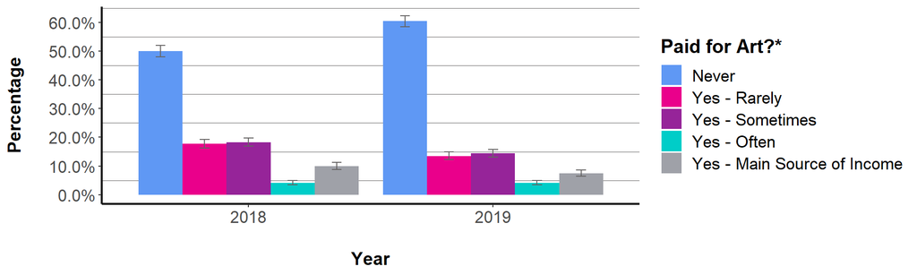

Error bars indicate the upper and lower bounds of the 95% confidence intervals.

* This question has been asked intermittently in the online survey over the last few years, however changes made in 2018 make direct comparison between years impossible. The plot above and table below represent 2018 and 2019 data only.

|  | 2018 Percent | 2018 MoE +/- % |  | 2019 Percent | 2019 MoE +/- % |
| --- | --- | --- | --- | --- | --- |
| Never | 50.0 | 2.0 |  | 60.4 | 2.0 |
| Yes - Rarely | 17.7 | 1.4 |  | 13.5 | 1.4 |
| Yes - Sometimes | 18.3 | 1.4 |  | 14.4 | 1.4 |
| Yes - Often | 4.1 | 0.8 |  | 4.2 | 0.8 |
| Yes - Main Source of Income | 9.9 | 1.2 |  | 7.5 | 1.0 |

**Next:** Sociodemographic Characteristics: Residence in the Default World, Language, Political Perspectives, Spiritual Perspectives